# The Perruchet Effect

Andy Wills and Paul Sharpe

## Before you start…

This is an advanced worksheet, which assumes you have completed the [Absolute Beginners’ Guide to R](https://ajwills72.github.io/rminr/#beginners) course, the Research Methods in Practice (Quantitative section) course, and the [Intermediate Guide to R](https://ajwills72.github.io/rminr/#rmip) course.

## Contents

- Overview
- Getting data from OSF
- Loading data
- De-duplicating data
- Excluding participants
- Graphing GSR
- Baseline correction
- Functions and loops
- Trial-level summary
- Adding a second DV
- List participant numbers
- More on loops
- Log transform
- Removing trials
- Recoding data
- Reporting means
- Better graphs
- More on Bayesian linear regression

## Overview

This worksheet describes a full analysis pipeline for an undergraduate student dissertation on the Perruchet Effect. The experiment was basically identical to the experiment described by McAndrew et al. (2012), except that the electric shock was replaced by a loud unpleasant noise (a metal garden fork scraping across slate). For details of the procedure, see the McAndrew paper, but here’s a very brief summary:

This was a conditioning experiment. A shape (brown cylinder, known as a *conditioned stimulus*, or ‘CS’) appears on the screen for 8 seconds. On 50% of occasions, this is then followed by the unpleasant noise (the *unconditioned stimulus* or ‘US’). The participant’s reaction to each CS is measured in two ways:

1. While the CS is on the screen, they are asked to rate their expectancy of the US on each trial, using a numerical scale. Higher ratings indicate greater conscious expectation of the unpleasant noise.
2. Throughout the experiment, their Galvanic Skin Response, a.k.a. [electrodermal activity](https://en.wikipedia.org/wiki/Electrodermal_activity) is measured. This is a measure of physiological arousal, greater numbers mean more arousal. Higher arousal is interpreted as greater unconscious expectancy of the unpleasant noise.

So, we have two dependent variables - expectancy ratings, and GSR. There is also one independent variable - “run length”. This relates to how many trials in a row you have experienced the unpleasant noise. For example, a “+3” trial means you have experienced the noise three times in a row; a “-2” trial means you have experienced the absence of the noise two trials in a row. The run lengths in this experiment range from -3 to +3.

There are two predictions. The first prediction is that the GSR will increase with run length, because the unconscious association between the shape and the noise will grow with repeated pairings. The second prediction is that the conscious expectancies will do the opposite - they will *decrease* with run length. This is known as [Gamblers’ Fallacy](https://ajwills72.github.io/critical-thinking/EvaluatingRisk.html) - in this case, the belief that, even though the sequence is random, a run of unpleasant noises means the next trial is more likely to be silent. This result is often taken to be one of the strongest pieces of evidence for a dual-process theory of learning, i.e. that we have unconscious and conscious learning processes that act somewhat independently of each other. This is because it can be hard to see how a single learning process could believe two things at the same time e.g. that on the +3 trials, it was simultaneously most and least likely that an unpleasant noise would occur.

## Getting data from a public repository

A basic principle of open science is that you publicly share your raw data (in anonymized form). The anonymized data used in this worksheet is preserved in this archive under `src/data/`, so the exercise does not depend on the OSF copy remaining available.

So, first, create a new project in R.

Next, **create a new, empty R script and save it as `perruchet.R`. Put all the commands from this worksheet into `perruchet.R`, and run them from there**. Save your script regularly.

Now, copy `src/data/DATA.csv`, `src/data/MAIN.csv`, and `src/data/codebook.md` into a `data` folder in your R project.

**Enter these commands into your script, and run them:**

```r
## Load data from OSF (commands only need to be run once)
## The data files are copied locally before this worksheet begins.
```

### Explanation of commands

The data files are supplied with this archive and copied into the project before the analysis. This keeps the worksheet usable if the original OSF project changes or becomes unavailable.

### Looking at the downloaded files

You can ignore the file `MAIN.csv`, which we’re not going to use. The first file you should open is `codebook.md`. A codebook is a file that explains what each of the columns in a data files means. Read the codebook and, while you’re reading through, look at the data file it is talking about, `DATA.csv`. It is this file on which all the following analysis is based.

## Loading data

As with any analysis, the first step is to load the data into R.

**Enter these commands into your script, and run them:**

```r
## Load packages, data. Rename data frame columns
library(tidyverse)
raw <- read_csv("data/DATA.csv")
colnames(raw) <- c("subj", "time", "key", "value")
```

### Explanation of commands

The second and third lines should be familiar from previous worksheets; we nearly always need the `tidyverse` package, and we use the `read_csv` command to load the data. The `data/` part of the filename `data/DATA.csv` says that the file `DATA.csv` is to be found in the directory (folder) called `data`.

The final line renames the columns, as covered in the Preprocessing data from experiments worksheet. I didn’t like the names of the columns very much so I changed them to something more comprehensible and quicker to type, using the `colnames` command.

## De-duplicating data

We’re now going to get the data into a state where we can meaningfully analyse it. The following commands were fully explained in the data preprocessing for experiments worksheet.

**Enter these commands into your script, and run them:**

```r
## De-duplicate data; remove pilot study
raw <- distinct(raw)
raw  <- raw %>% filter(subj > 161)
```

## Excluding participants

Participants in this experiment were told to rate their expectancy of the US during the CS, *on every trial*. However, they only had 8 seconds to do this, and the experimenters noticed that sometimes people failed to make a rating. The experimental apparatus records this as a rating of zero.

Participants who miss a lot of ratings aren’t really following the instructions, making their data hard to interpret. In such cases, we normally exclude those participants from further analysis. The following commands were fully explained in the data preprocessing for experiments worksheet.

**Enter these commands into your script, and run them:**

```r
## Number of expectancy ratings, by participant
inspect  <- raw %>% filter(key == "ER") %>% filter(value == 0)
table(inspect$subj)
```

```
163 164 166 176 184 188 191 196 199 202 223 233 235 236 239 246
  1  19  46  16   2   3   2   1  32   3   3   1   3   9  34   1
```

```r
## Exclude participants
exclude  <- c(164, 166, 176, 199, 236, 239)
raw  <- raw %>% filter(!(subj %in% exclude))
```

### Note

There are still a few trials where the participant makes no expectancy rating, and the computer records this as an expectancy of zero. There’s a good case to be made for recoding the rating on those trials as either `NA` (meaning ‘missing data’) or `3`, meaning “participant is unsure whether the noise will occur”. For brevity, we don’t make these changes here, but once you’ve gone through the whole worksheet, perhaps try to work out how one might do this.

## Graphing GSR

The GSR data from this experiment is very rich, with a skin conductance measure taken from each participant approximately twenty times a second throughout the whole 30-40 minutes of the experiment. To ‘get a feel’ for these data, and also to check that the equipment was working properly, we need to plot that GSR as a graph, with time on the x-axis and GSR on the y-axis. We’ll need to do this one participant at a time, otherwise the graph will be really hard to read.

**Enter these commands into your script, and run them:**

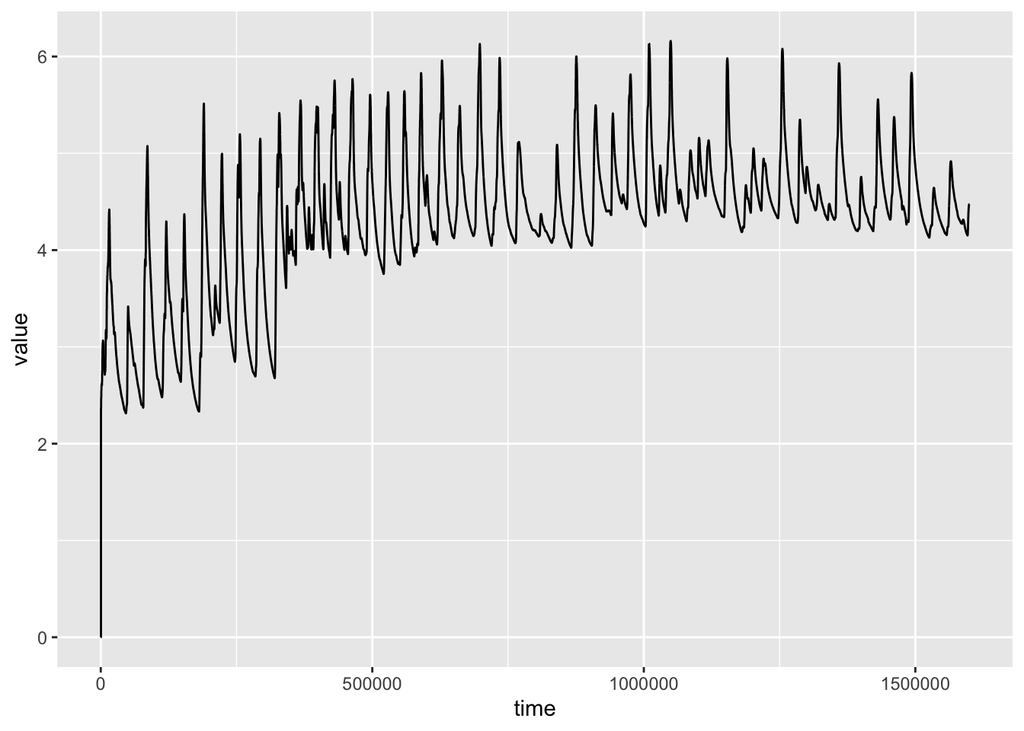

```r
## GSR plot
dat  <- raw %>% filter(subj == 168)
gsr <- dat %>% filter(key == "GS")
gplot <- gsr %>% ggplot(aes(x=time, y=value)) + geom_line()
gplot
```

### Explanation of commands

The second line should be familiar, we’ve filtered the data to include just one participant (168).

The third line is also a simple filter operation - we’re keeping just those rows where the `key` column says `GS`. From `codebook.md`, we can see that this means the rows of the data file that contain GSR readings.

The fourth line should also be pretty familiar, we’re just doing a standard line graph, as we previously covered in, for example, the Understanding Interactions worksheet. In this case, we save the line plot in an object called `gplot`, and then show the graph by typing `gplot` as the last command. We do it this way so we can add other things to the graph later.

### Explanation of output

We can see the GSR going up and down over time. Why is it doing that? Our assumption is that this is people reacting to the CS (cylinder), which is sometimes followed by the US (noise). We can check this by adding a vertical line to the graph for the time each CS occurs.

## Adding CS onsets to our graph

We can add CS onset times like this; **enter these commands into your script, and run them:**

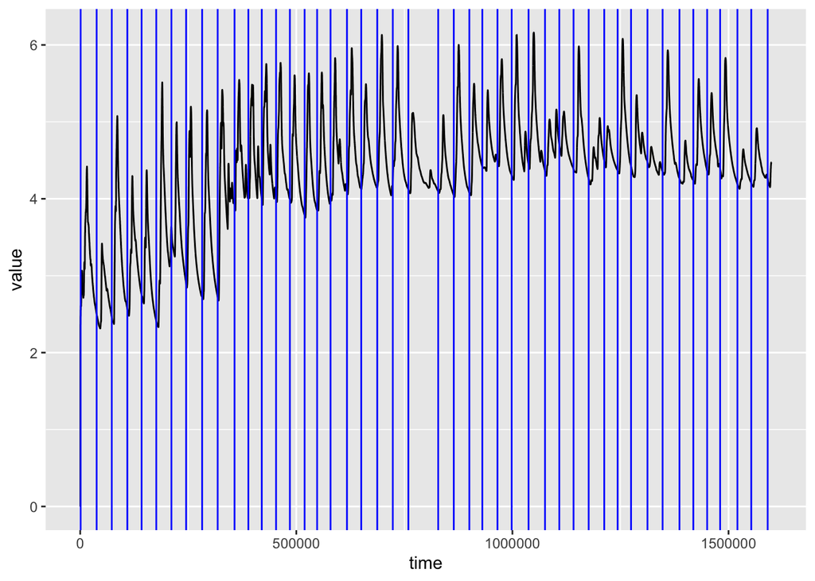

```r
## Add CS onset times to graph
cs <- dat %>% filter(key == "CO")
gplot <- gplot + geom_vline(data=cs, mapping=aes(xintercept=time),
                            colour="blue")
gplot
```

### Explanation of commands

The second line should be familiar - we are selecting those rows of the data that contain the key `CO`, which `codebook.md` tells us are the timings of the CS onsets.

We’ve also come across `geom_vline` before, as part of the Putting R to work worksheet - it just plots a vertical line at a place we ask it to. The new part of this command is `data=cs, mapping=aes(xintercept=time)`. Previously, we’ve just told R manually where we want the line (e.g. `xintercept = 4.35`). Now, we’re telling it that we want a bunch of lines, that the `data` for the position of those lines is to be found in `cs` data frame, and that the `time` column of that data frame should be used to find them.

Here, we’re adding the vertical lines to the plot we’ve already made `gplot <- gplot + geom_vline...`, and then showing the updated graph, `gplot`.

### Explanation of output

There appears to be a missing blue line in the middle. Actually, there isn’t, it’s just that the participant was given a break half way through the experiment, so there wasn’t a CS for a while. What we can also see, however, is that the GSR seems to go up each time there’s a CS, and then go back down again. Sometimes that’s quite a big rise, and sometimes, less big. If the experiment worked out as we expected, then the size of the GSR reaction will depend on the run length. We’ll look at this later on, but first we need to do some preprocessing.

## Baseline correction

One problem with GSR data (and much other neuroscience data, e.g. EEG, fMRI) is that it’s both highly variable (“noisy”), and changes systematically over time (“drift”). By ‘noisy’, we mean that, for a given event in the world, the GSR response to that event varies quite a lot, even if the event itself is objectively identical. In order to deal with this noise, we average the participant’s GSR over several trials, and so get a sense of what their typical response is.

By ‘drift’, we mean that these differences across trials are not random, they are affected by systematic changes in the participant over time. For example, as they hear more and more unpleasant noises, perhaps the noise becomes less unpleasant to them (“habituation”), and so their GSR reaction late in the experiment might be smaller than their GSR reaction early in the experiment. Another example – once someone’s GSR goes up, it can take quite a lot of time to go back down again (“return to baseline”). In this experiment, we waited a long time between trials, the *inter-trial interval* was around 30 seconds. However, this is often not enough, and we find that sometimes their GSR has not returned to baseline by the time the next CS appears.

The combination of noise and drift means that, not only do we need to average across a lot of trials, we also need to try and make those trials more comparable to each other before we average them. The process we use to do that here is *baseline correction*. This is simply a subtraction. We calculate the average GSR response in the 500 ms before the CS arrives (the *baseline*), and then we subtract that baseline from all the GSR readings while the CS is present.

Let’s illustrate this with a single trial from participant 168. For no particular reason, let’s take trial 10.

**Enter these commands into your script, and run them:**

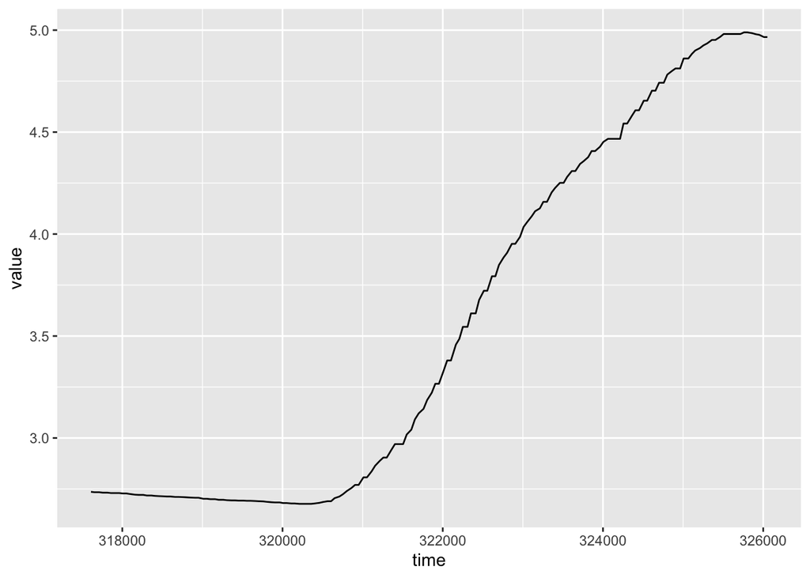

```r
## Plot a single trial
onset  <- cs$time[10]
full <- gsr %>% filter(time >= onset - 500 & time <= onset + 8000)
full %>% ggplot(aes(x=time, y=value)) + geom_line()
```

### Explanation of commands

Line 2 - In order to find a single trial, we need to know at what time the CS began on that trial. We already have those CS onset times from doing the last graph, so we just ask R for the `10`th row of the `time` column of that `cs` data frame - `cs$time[10]` - and record it as `onset` (with `onset <-`)

Line 3 - Now we know where the CS starts, we need to take all the GSR readings from 500 ms before that (our *baseline*), up to 8000 ms after that (when the CS ends). We use the now-familiar `filter` command to do this.

Line 4 - Just a plain old line graph.

### Explanation of output

What we see in the graph is just a ‘zoomed in’ part of the previous graph - for the 10th trial, 500 ms before the CS onset to 8000ms after the CS onset. The x-axis has large numbers because time is counted from the start of the experiment, in milliseconds. The line looks a bit ‘jagged’ because the equipment is has limited accuracy in measuring GSR.

## Applying baseline correction

Now, we need to do two things.

First, we need to apply the baseline correction to these data. In other words, we work out the average GSR in the 500ms before the CS arrives; we then subtract that average from every data point, so the first 500 ms of the graph will always be around zero.

Second, we’re going to need to average all these trials, so we need the x-axis to be the same for all of them. To do this, we subtract the onset time from all the values on the x-axis, meaning we end up with data that goes from -500 ms to +8000 ms.

We can do all this in four lines of code, plus one to plot the new graph.

**Enter these commands into your script, and run them:**

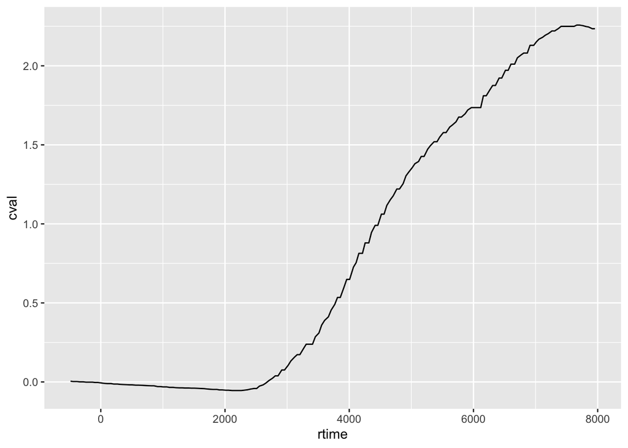

```r
## Basline correct that trial, and replot
precs  <- gsr %>% filter(time >= onset - 500 & time < onset)
correct  <- mean(precs$value)
full <- full %>% mutate(cval = value - correct)
full <- full %>% mutate(rtime = time - onset)
full %>% ggplot(aes(x=rtime, y=cval)) + geom_line()
```

### Explanation of commands

Line 2 - Use `filter` to select the GSR values for the baseline period i.e. 500ms before the CS onset until the CS onset, and put them in a dataframe called `precs`.

Line 3 - Calculate the mean of the GSR values in this pre-CS period (`precs$value`) and store it in `correct`.

Line 4 - Using the command `mutate`, we create a new column in the `full` data frame called `cval` (for “corrected value”). This column contains the numbers in the `value` column, minus the baseline correction we’ve just calculated (`correct`). The name `mutate` is perhaps a bit odd, but “mutate” is just another word for “change” (over and above it’s other biological, and sci-fi connotations…). So, `mutate` here just means create a new column by changing an existing one.

Line 5 - Using `mutate` again, we create another column called `rtime` (for “relative time”). This is just the actual time, minus the time the CS arrived. So, the CS arrival time will always be zero.

Line 6 - Just another line graph

### Explanation of output

We get another graph, which at first sight looks exactly like the last one. The thing to notice is that the x-axis and y-axis now have different numbers - the CS onset is at 0 ms rather than 318000 ms, and the GSR line starts at 0 rather than around 2.5.

## Functions and loops

In principle, we could do this baseline correction for each trial of each participant in the same way as the above example. However, this would be really tedious, because there are about 50 participants and 50 trials per participant, so about 2,500 trials in total!

When we want R to do the same thing many times, we can use *functions* and *loops* to achieve this. We’ll look at *functions* first.

### Defining a function

Pretty much every command you run in R is a function that someone has written. For example, `mean(precs$value`) uses the function `mean()`, which is built in to R. The command `read_csv` is a function added to R by loading the `tidyverse` library. You can also write your own functions. Here’s a function that contains all the commands we used to baseline-correct one trial of participant 168:

**Enter these commands into your script, and run them:**

```r
## Define function for baseline correction
base.correct  <- function(trial) {
    onset  <- cs$time[trial]
    full <- gsr %>% filter(time >= onset - 500 & time <= onset + 8000)
    precs  <- gsr %>% filter(time >= onset - 500 & time < onset)
    correct  <- mean(precs$value)
    full <- full %>% mutate(cval = value - correct)
    full <- full %>% mutate(rtime = time - onset)
    full  <- full %>% add_column(trial = trial, run = cs$value[trial])
    return(full)
}
```

Ignoring the first and the last two lines for a moment, notice that these commands are almost identical to the ones we just used. The only difference is that we’ve changed `cs$time[10]` to `cs$time[trial]`. So, instead of always looking at trial 10, we look at whatever trial is specified by `trial`, and that is set by calling the function. A function doesn’t do anything until we ask it to, by ‘calling’ it. So, for example, we can now look at trial 9 by calling the `base.correct` function like this:

**Enter these commands into your script, and run them:**

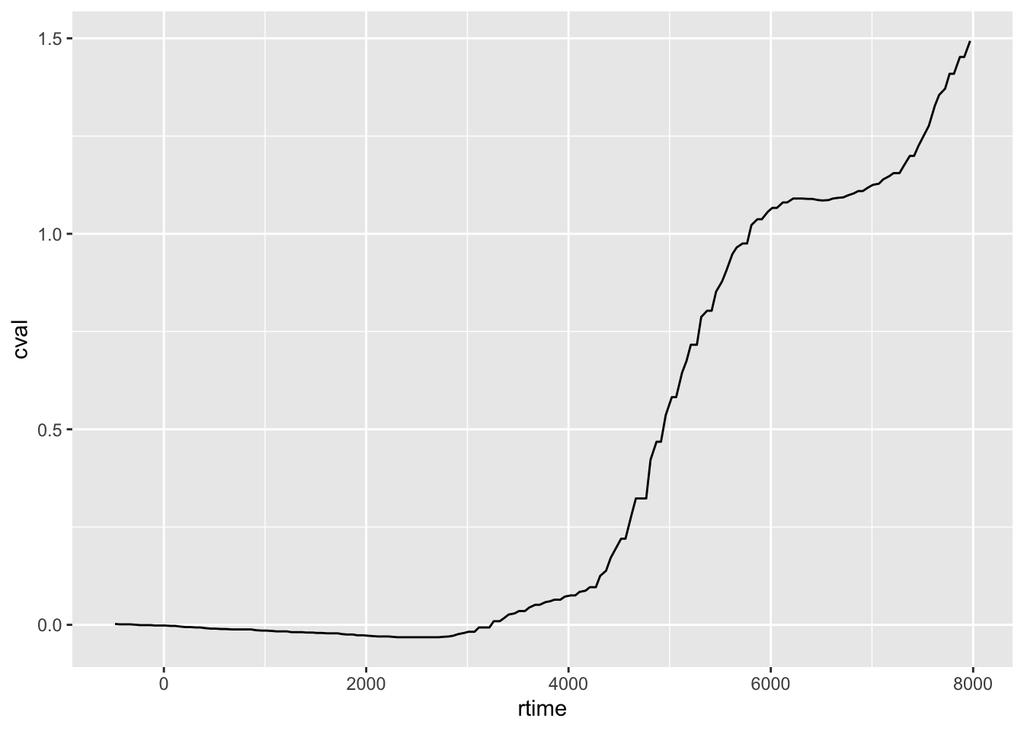

```r
eg  <- base.correct(9)
eg %>% ggplot(aes(x=rtime, y=cval)) + geom_line()
```

The first and last two lines of the `base.correct` code are what makes it a *function*. The first line tells R to create a `function` called `base.correct`, and that this function takes an input called `trial`. The `{` indicates the start of the commands in the function. The `}` in the last line of code indicates the end of the set of commands in the function. The penultimate line, `return(full)`, means that the function returns the `full` data frame it has calculated.

So, when we type `eg <- base.correct(9)`, the function we have written does the baseline correction for trial 9, and returns the answers. We put these answers into `eg` (using `eg <-`), and then plot the graph.

There’s one line of the function we have not yet discussed:

`full <- full %>% add_column(trial = trial, run = cs$value[trial])`

The key aspect of this command is `add_column` which, perhaps unsurprisingly, adds new columns to a data frame. In this case, we are adding two columns to the right hand side of the data frame. These are going to be useful later. The first column contains the `trial` number, and the second column contains the *run length* (-3 to +3, see description of experiment). The run length is recorded along with the CS onset time data, in the `value` column (see `codebook.md`) so we read the run length for the current trial using `cs$value[trial]`.

### Using a loop

We can now use a loop to run this function for every trial of one participant. We’ve used loops in a similar way before, to combine data files from multiple participants using `bind_rows`, see the preprocessing data from experiments worksheet.

**Enter these commands into your script, and run them:**

```r
## Use a loop to baseline correct all 46 trials
onep  <- NULL
for(trial in 1:46) {
    onep  <- bind_rows(onep, base.correct(trial))
}
```

### Explanation of command

The loop runs `base.correct(trial)` for each of the 46 trials the participant did, and adds them all to one big data frame called `onep`. In more detail:

`onep <- NULL` - Set up an empty (`NULL`) dataframe to put our results in.

`for(trial in 1:46) {` - `1:46` means the whole numbers from 1 to 46. So, the first time we go round this loop, `trial` is `1`, the second time it is `2`, and so on. When we get to `46`, the loop runs for the last time.

`onep <- bind_rows(onep, ...)` - Bind (attach) some new rows to `onep` :

`base.correct(trial)` - The trials to bind are those that come out of `base.correct(trial`).

## Trial-level summary

Let’s take a look at what we’ve generated.

**Enter these commands into your script, and run them:**

```r
onep
```

```
# A tibble: 7,819 × 8
    subj  time key   value    cval rtime trial   run
   <dbl> <dbl> <chr> <dbl>   <dbl> <dbl> <int> <dbl>
 1   168   551 GS     2.37 -0.0839  -451     1     0
 2   168   602 GS     2.37 -0.0839  -400     1     0
 3   168   651 GS     2.46  0.0111  -351     1     0
 4   168   702 GS     2.46  0.0111  -300     1     0
 5   168   752 GS     2.48  0.0291  -250     1     0
 6   168   801 GS     2.48  0.0291  -201     1     0
 7   168   851 GS     2.48  0.0291  -151     1     0
 8   168   902 GS     2.48  0.0291  -100     1     0
 9   168   952 GS     2.48  0.0291   -50     1     0
10   168  1002 GS     2.54  0.0941     0     1     0
# ℹ 7,809 more rows
```

The dataframe `onep` contains all the GSR data during the CS presentations(and the baseline) for one participant, including columns that record the trial each reading comes from, and the *run length* of that trial (see experiment description). Each trial is 8.5 seconds of readings at about 20 readings a second and 46 trials, giving us about 7820 readings in total for this participant.

For the purposes of analysis, we need to summarize this data down to just one number per trial, representing how large the GSR was on that trial. There’s a few ways one could do this; here we’re just going to take the average GSR for trial.

**Enter these commands into your script, and run them:**

```r
## Calculate mean GSR for each trial
gsr.sum  <- onep %>%
    filter(rtime >= 0) %>%
    group_by(trial, run) %>%
    summarise(cval = mean(cval))
```

```
`summarise()` has regrouped the output.
ℹ Summaries were computed grouped by trial and run.
ℹ Output is grouped by trial.
ℹ Use `summarise(.groups = "drop_last")` to silence this message.
ℹ Use `summarise(.by = c(trial, run))` for per-operation grouping
  (`?dplyr::dplyr_by`) instead.
```

```r
gsr.sum
```

```
# A tibble: 46 × 3
# Groups:   trial [46]
   trial   run    cval
   <int> <dbl>   <dbl>
 1     1     0  0.361
 2     2    -1 -0.109
 3     3     1  0.181
 4     4     0  0.125
 5     5    -2  0.0404
 6     6     1  0.0714
 7     7     0 -0.252
 8     8     0  0.644
 9     9    -3  0.427
10    10     0  0.874
# ℹ 36 more rows
```

### Explanation of command

Line 3 - We remove all GSR recordings from the baseline period (where `rtime` is less than zero)

Lines 4-5 - We group the data by `trial` and by `run` length, and then `summarise` this group data by taking the mean corrected value, `cval`.

### Explanation of output

The output shows the contents of `gsr.sum`. Each row is one trial. For each trial, we have the *run length*, and the mean GSR response `cval`. Later on, we’ll analyze these data - but first, we have to finish the preprocesssing.

## Adding a second dependent variable

The data frame `onep` contains a GSR for each trial, but there is also an expectancy rating for each trial. It will make it easier to look at these data if we also include these expectancy ratings into `onep`. So, using the following commands, we first create a new data frame with the expectancy ratings.

**Enter these commands into your script, and run them:**

```r
## Extract expectancy ratings
expect <- dat %>% filter(key == "ER") %>% add_column(trial = 1:46) %>% select(subj, trial, value)
expect
```

```
# A tibble: 46 × 3
    subj trial value
   <dbl> <int> <dbl>
 1   168     1     2
 2   168     2     3
 3   168     3     3
 4   168     4     2
 5   168     5     4
 6   168     6     4
 7   168     7     3
 8   168     8     3
 9   168     9     4
10   168    10     4
# ℹ 36 more rows
```

### Explanation of command

We take the full data for one participant (`dat`) and then `filter` it to retain only the rows marked `ER` (the *expectancy rating* rows, see `codebook.md`). We then add a new column (`add_column`) that is called `trial` and contains the numbers 1 to 46 (`1:46`). Finally, we select just the `subj`, `trial`, and `value` columns of that dataframe, and place them into `expect`.

### Explanation of output

The dataframe `expect` contains one row for each trial, and the column `value` contains the expectancy rating for that trial.

### Combining expectancy and GSR data

In the final step of preprocessing this participant, we join the expectancy ratings `expect` and the mean GSRs (`gsr.sum`) into a single data frame.

**Enter these commands into your script, and run them:**

```r
## Combine GSR and expectancy data
comb.data  <- full_join(gsr.sum, expect, by = "trial")
comb.data
```

```
# A tibble: 46 × 5
# Groups:   trial [46]
   trial   run    cval  subj value
   <int> <dbl>   <dbl> <dbl> <dbl>
 1     1     0  0.361    168     2
 2     2    -1 -0.109    168     3
 3     3     1  0.181    168     3
 4     4     0  0.125    168     2
 5     5    -2  0.0404   168     4
 6     6     1  0.0714   168     4
 7     7     0 -0.252    168     3
 8     8     0  0.644    168     3
 9     9    -3  0.427    168     4
10    10     0  0.874    168     4
# ℹ 36 more rows
```

### Explanation of command

The command `full_join` joins together two separate data frames, using a column they have in common. In this case, the `gsr.sum` and `expect` data frames have the `trial` column in common.

## List of participant numbers

We’ve now completed the preprocessing of one participant (`168`). In principle, we could go through all the same steps for each of the other approximately 50 participants, but that would be rather tedious. Instead, we can use a *loop* to automate this for us, as we’ll see in a minute, but first we need to get a list of participant numbers.

**Enter these commands into your script, and run them:**

```r
## Create list of participant numbers
subjs <- enframe(unique(raw$subj))
subjs
```

```
# A tibble: 43 × 2
    name value
   <int> <dbl>
 1     1   200
 2     2   198
 3     3   197
 4     4   196
 5     5   195
 6     6   193
 7     7   191
 8     8   188
 9     9   186
10    10   184
# ℹ 33 more rows
```

### Explanation

We need a list of the different participant numbers used in this experiment. We can get this using the `subj` column of the `raw` data, so `raw$subj`. The only problem is that each subject number occurs many times (once for each GSR recording, so 20 times a second). We want just one copy of each different subject number. The command `unique` does that for us, so the command `subjs <- enframe(unique(raw$subj))` gives us the participant numbers (`enframe` just means ‘put in a data frame’).

## More on loops

**Enter these commands into your script, and run them:**

```r
## Baseline correct all trials for all participants
sum.data  <- NULL
for(this.subj in subjs$value) {
    dat  <- raw %>% filter(subj == this.subj)
    gsr <- dat %>% filter(key == "GS")
    cs <- dat %>% filter(key == "CO")
    onep  <- NULL
    for(trial in 1:46) {
        onep  <- bind_rows(onep, base.correct(trial))
    }
    gsr.sum  <- onep %>%
        filter(rtime >= 0) %>%
        group_by(trial, run) %>%
        summarise(cval = mean(cval))
    expect <- dat %>%
        filter(key == "ER") %>%
        add_column(trial = 1:46) %>%
        select(subj, trial, value)
    comb.data  <- full_join(gsr.sum, expect, by = "trial")
    sum.data  <- bind_rows(sum.data, comb.data)
}
sum.data
```

```
# A tibble: 1,978 × 5
# Groups:   trial [46]
   trial   run    cval  subj value
   <int> <dbl>   <dbl> <dbl> <dbl>
 1     1     0  0.334    200     1
 2     2    -1 -0.118    200     4
 3     3     0  0.173    200     2
 4     4     0  0.124    200     4
 5     5     3  0.125    200     4
 6     6     0 -0.0832   200     2
 7     7     0  0.228    200     4
 8     8    -3  0.228    200     4
 9     9     1  0.0773   200     5
10    10     0  0.789    200     4
# ℹ 1,968 more rows
```

### Explanation of output

Our full set of preprocessed data, one row per participant per trial. We’ll use this in our analyses in the next step.

### Explanation of commands

You can safely ignore everything apart from the first two lines and the last three lines of commands. This is because the bit in the middle is exactly the same commands as we’ve been building up throughout this worksheet. They take one participant, baseline correct all their GSRs, take a mean GSR for each trial, and record that along with the expectancy rating, and information about trial (participant number, trial number, run length).

All of these commands are placed inside a `for` loop, which we’ve used before in this worksheet. We use the set of participant numbers (`subj$value`) we just collected and use the for loop to set `this.subj` to each of these values in turn. All the data is combined together in `sum.data`, using the `bind_rows` command we’ve used before.

## Log transform

There are three further preprocessing steps we have to take before we can analyze these data. First, studies of GSR data normally *log transform* it before analysis. The following commands were fully explained in the data preprocessing for experiments worksheet.

**Enter these commands into your script, and run them:**

```r
## Log transformation of GSR
sum.data  <- sum.data %>% mutate(lcval = log(cval+1))
```

## Removing trials

In our Perruchet Effect experiment, we have runs of various lengths. For example, for something to be a `+2` run there must be a sequence of four trials in the following order `NSSN` where N means no sound, and S means sound. The third trial in that sequence is a +2 trial, because there have been two sounds in a row, and on the following trial there will not be a sound so the run will end. Importantly, at least the way people normally analyse these data, the second trial in that sequence has no definable run length. One might say it is a `+1` trial because, at that point, there has only been one sound in a row. However, the experimenter knows that the run will continue on the next trial, so calling it a `+1` trial somehow doesn’t seem quite right (although, from the perspective of the participant, at the time they are reacting to that trial, clearly it is a `+1` trial).

Normally, these experimenter-ambiguous trials are described as having a zero run length, and are excluded from the analysis. Run length is recorded directly into the data file itself, so we can remove zero run-length trials as follows.

**Enter these commands into your script, and run them:**

```r
## Remove trials where run length is zero
sum.data  <- sum.data %>% filter(run != 0)
```

This is a standard `filter` command. The `!=` part reads as ‘not equal to’. So, this command keeps all the non-zero run lengths.

## Recoding data

Another convention of analyzing Perruchet effect experiments is that you convert run length (-3 to +3) into a dependent variable called “Level”. This involves coding `-3` and `+1` as Level 1, `-2` and `+2` as Level 2, and `-1` and `+3` as Level 3. If GSR rises from -3 to +3 run lengths, it will also rise from Level 1 to Level 3. Equally, if GSR drops from -3 to +3, it will also drop from Level 1 to Level 3. The reasons for recoding the dependent variable in this way are not straight forward, and are a matter of some debate. Nonetheless, as this experiment is essentially an attempt to replicate McAndrew et al.’s paper with an unpleasant noise, we chose to use the same analyses they did, and that involves recoding the run length as Level.

We covered recoding data in the *Cleaning up questionnaire data* part of Research Methods in Practice (Quantitative Section). To recode some data, we need to take two steps. First, we define the *mapping* - so, for each run length, what Level is that? We do this as follows.

**Enter these commands into your script, and run them:**

```r
## Define mapping of run length to Levels
level.code  <- c(`-3` = 1, `-2` = 2, `-1` = 3, `1` = 1, `2` = 2, `3` = 3)
```

So, for example, a run length of `-2` becomes a Level of `2`.

Once we have our mapping, we can use it, via `mutate` to create a new column called `level`. We use the `recode` command to do this, converting the column `run` using the mapping `level.code` we’ve just written. The `!!!` part probably isn’t worth spending the time to understand deeply, but if you’d like to dig deeper, see the explanation in Research Methods in Practice (Quantitative Section).

**Enter these commands into your script, and run them:**

```r
## Recode run length as Levels
sum.data <- sum.data %>% mutate(level = recode(run, !!!level.code))
```

Finally, we create a new participant-level summary of our data, using `level` (rather than `run`, as `sum.data` did).

**Enter these commands into your script, and run them:**

```r
## Summarize GSR and expectancy, by Level, for each participant
lvl.sum  <- sum.data %>%
    group_by(subj, level) %>%
    summarise(lcval = mean(lcval), expect = mean(value))
```

```
`summarise()` has regrouped the output.
ℹ Summaries were computed grouped by subj and level.
ℹ Output is grouped by subj.
ℹ Use `summarise(.groups = "drop_last")` to silence this message.
ℹ Use `summarise(.by = c(subj, level))` for per-operation grouping
  (`?dplyr::dplyr_by`) instead.
```

## Reporting means

The preprocessing is done! As a first, quick test of our hypotheses, we can just take a peek at the mean GSR and expectancy rating, across all participants, for each Level. We use the familiar `group_by` and `summarise` commands to do this.

**Enter these commands into your script, and run them:**

```r
## Overall mean GSR and expectancy, by Level
mdata  <- lvl.sum %>% group_by(level) %>% summarise(lcval = mean(lcval), expect = mean(expect))
mdata
```

```
# A tibble: 3 × 3
  level  lcval expect
  <dbl>  <dbl>  <dbl>
1     1 0.0527   3.64
2     2 0.0383   3.18
3     3 0.0203   2.81
```

From these results, we can see that expectancy reduces with Level, as expected. Somewhat surprisingly, the GSR (`lcval`) shows the *same* trend, GSR reduces with increased Level. This is opposite to what McAndrew et al. reported in their experiment. Below, we’ll investigate further, first using graphs and then using linear regression.

## Better graphs

The simplest graph we could produce here would be to just plot the three means reported above, but this wouldn’t really add anything to what we’ve already done; the trend is clear just from the three numbers. Instead, we did the following.

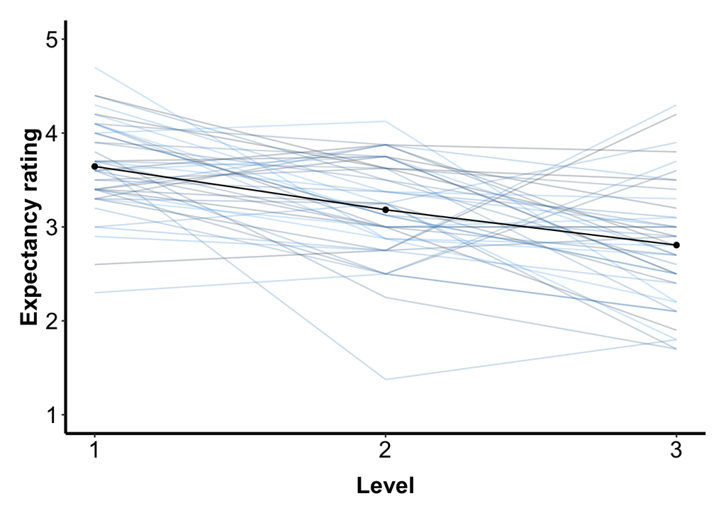

From this plot, it’s clear that: (a) the overall trend is downwards, (b) most but not all participants individually show this trend, and (c) there is some variation in the absolute ratings people use.

A full explanation of how we built this graph can be found in the better graphs worksheet.

### Graphing GSR

We can now follow exactly the same procedure to produce a second graph, for GSR.

**Enter these commands into your script, and run them:**

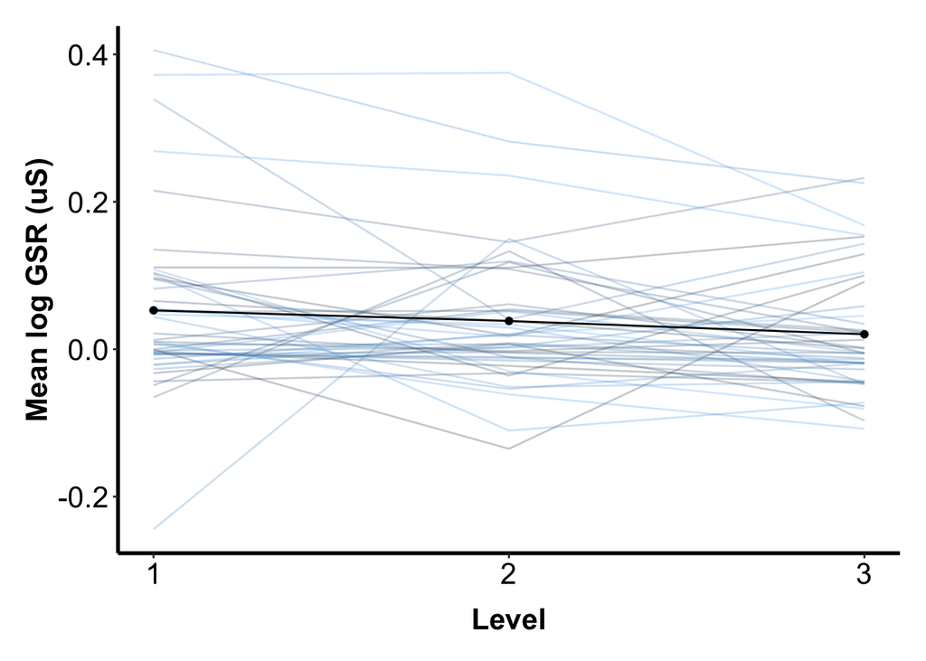

```r
### Plot GSR by Level
lns  <- geom_line(aes(x=level, y=lcval, group=subj, colour=subj), data = lvl.sum, alpha = .25)
mline  <- geom_line(aes(x=level, y=lcval), data = mdata, colour="black")
mdot  <- geom_point(aes(x=level, y=lcval), data = mdata, colour="black")
base + lns + mline + mdot + xlab("Level") +
    ylab("Mean log GSR (uS)") + scale_x_continuous(breaks = c(1,2,3))  + theme_APA +
    theme(legend.position="none")
```

We can see from this plot that the GSR data is a lot more variable than the expectancy data, and that the downward trend is less obvious at the level of individual participants - many participants show either largely flat lines, or lines that clearly do not show an overall downward trend.

## More on Bayesian linear regression

In the within-subject differences worksheet you learned how to apply a Bayesian ANOVA to data from within-subjects manipulations, and in the Research Methods in Practice (Quantitative Section) course, you learned how to apply a Bayesian linear regression to a set of between-subjects data. To analyze these data, we need to combine those two techniques.

First, some preliminaries.

**Enter these commands into your script, and run them:**

```r
## Load BayesFactor pacakge; define subject as factor
library(BayesFactor, quietly=TRUE)
lvl.sum$subj  <- factor(lvl.sum$subj)
```

In line 2, we load the `BayesFactor` package, which we use to do Bayesian ANOVAs and regressions. In line 3, we set the participant numbers as factors, for the reasons discussed in the within-subject differences worksheet. Note that we don’t set the Level column of `lvl.sum` as a factor, because the our three Levels are ordered - 1, 2, 3.

The first step in our analysis is identical to a Bayesian ANOVA, except we use the command `lmBF` instead of `anovaBF`. Note that, just like in `anovaBF`, we need to tell R that these data come from many different participants, hence the `+ subj` and `whichRandom = "subj"` parts of the command.

**Enter these commands into your script, and run them:**

```r
## Bayesian regression model on GSR, by Level
g.level  <- lmBF(lcval ~ level + subj, data = data.frame(lvl.sum), whichRandom = "subj")
g.level
```

```
Bayes factor analysis
--------------
[1] level + subj : 68428267 ±1.07%

Against denominator:
  Intercept only
---
Bayes factor type: BFlinearModel, JZS
```

It’s pretty self-evident from the graphs that there are some individual differences. More critically, if we want evidence that it is specifically the Level that affects GSR, over and above individual differences, then we need to compare our experimental hypothesis (`lcval ~ level + subj`) with the alternative hypothesis that there are just individual differences (`lcval ~ subj`). We do this in much the same way that we test for an interaction in a Bayesian ANOVA.

More specifically, we create a model in which only individual differences affect the GSR…

**Enter these commands into your script, and run them:**

```r
## Individual differences baseline model
g.subj  <- lmBF(lcval ~ subj, data = data.frame(lvl.sum), whichRandom = "subj")
```

…and then we compare the two models by dividing one by the other:

**Enter these commands into your script, and run them:**

```r
## Bayes Factor for GSR, by Level
g.level / g.subj
```

```
Bayes factor analysis
--------------
[1] level + subj : 1.92539 ±1.07%

Against denominator:
  lcval ~ subj
---
Bayes factor type: BFlinearModel, JZS
```

From the output, we can see that the relevant Bayes Factor is around 1.9. So, there is some evidence for the hypothesis that GSR drops with Level in our experiment, but that evidence is quite weak (BF < 3).

### Linear regression of expectancies

We can now follow the same procedure for the expectancy ratings.

**Enter these commands into your script, and run them:**

```r
## Bayes Factor for expectancy, by Level
e.level  <- lmBF(expect ~ level + subj, data = data.frame(lvl.sum), whichRandom = "subj")
e.subj  <- lmBF(expect ~ subj, data = data.frame(lvl.sum), whichRandom = "subj")
e.level / e.subj
```

```
Bayes factor analysis
--------------
[1] level + subj : 282714555 ±6.65%

Against denominator:
  expect ~ subj
---
Bayes factor type: BFlinearModel, JZS
```